# Coursera Data Products Class Project

October 23, 2017

## Introduction

- Company ACME maintains an inventory of pumps for sale
- These pumps are expensive and have a lead time from their supplier of 6 months
- The company would like to have enough pumps on hand to meet demand but not so many that they sit in inventory for months
- They have historical data for demand expressed as monthly sales average and standard deviation (normal distribution)
- They would like to use a Monte Carlo method to estimate when the probability of running out of pumps is greater than 10% in the next 6 months so they know when to order more

## Calculation method

- An R script was written to calculate scenarios based on historical data
- The inputs for the script are:
1. Average monthly pump usage
2. Standard deviation of monthly usage
3. Quantity on hand in inventory
- The script then performs 2000 (user input) simulations where:
1. A monthly usage is calculated for each of the next 6 months using a normal random distribution
2. That number is subtracted from the initial inventory
- At the end of the 2000 simulations, the probability of having zero pumps in inventory for each month is calculated
- The result is presented in graphical form to the user for a purchasing decision

## Results

The results for a calculation are shown. The inputs were:

- Initial inventory of 55 pumps
- Monthly average usage of 10 pumps with a standard deviation of 3.5 pumps

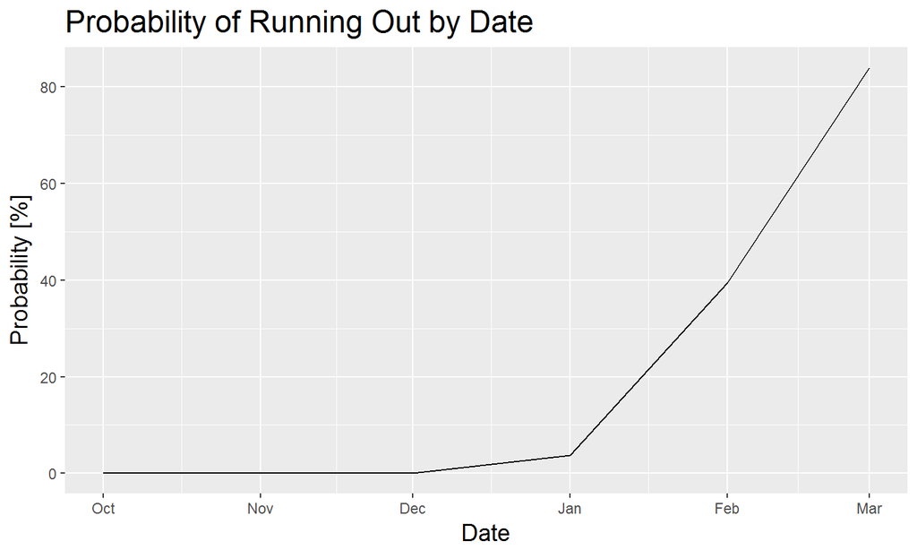